# Lecture_1: R code

## Practical aspect of the lecture

```r
inequality<-read.table('inequality.txt',sep=',', header=T)#Reading the data in R
head(inequality)
```

```
##        state median_household_income share_unemployed_seasonal
## 1    Alabama                   42278                     0.060
## 2     Alaska                   67629                     0.064
## 3    Arizona                   49254                     0.063
## 4   Arkansas                   44922                     0.052
## 5 California                   60487                     0.059
## 6   Colorado                   60940                     0.040
##   share_population_in_metro_areas share_population_with_high_school_degree
## 1                            0.64                                    0.821
## 2                            0.63                                    0.914
## 3                            0.90                                    0.842
## 4                            0.69                                    0.824
## 5                            0.97                                    0.806
## 6                            0.80                                    0.893
##   share_non_citizen share_white_poverty gini_index share_non_white
```

[output cut: 20 more lines]

Probability density plots: outcomes

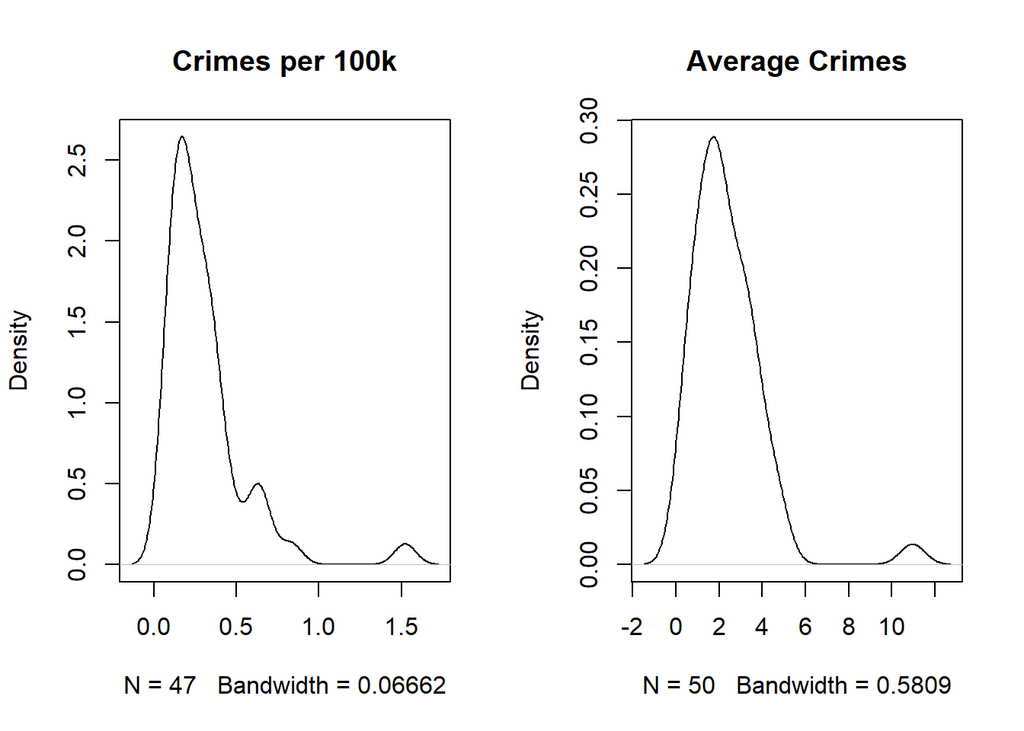

```r
par(mfrow=c(1,2))
plot(density(inequality$hate_crimes_per_100k_splc, na.rm = T), main='Crimes per 100k') #probability density for hate crimes outcomes. na.rm=T indicates that only cases that are not NAs should be returned
plot(density(inequality$avg_hatecrimes_per_100k_fbi, na.rm = T), main='Average Crimes')
```

Probability density plots: predictors

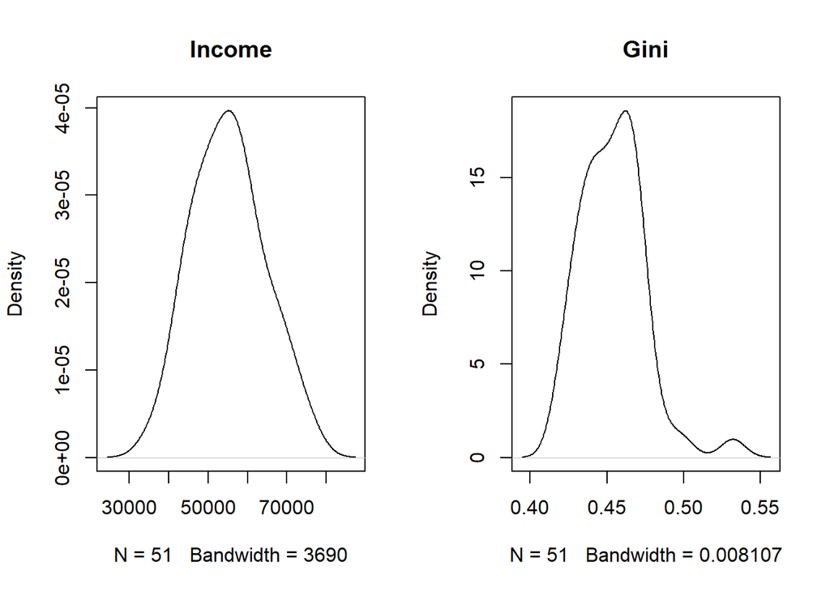

```r
par(mfrow=c(1,2))
plot(density(inequality$median_household_income, na.rm = T), main='Income')
plot(density(inequality$gini_index, na.rm = T), main='Gini')
```

Scatter plots:

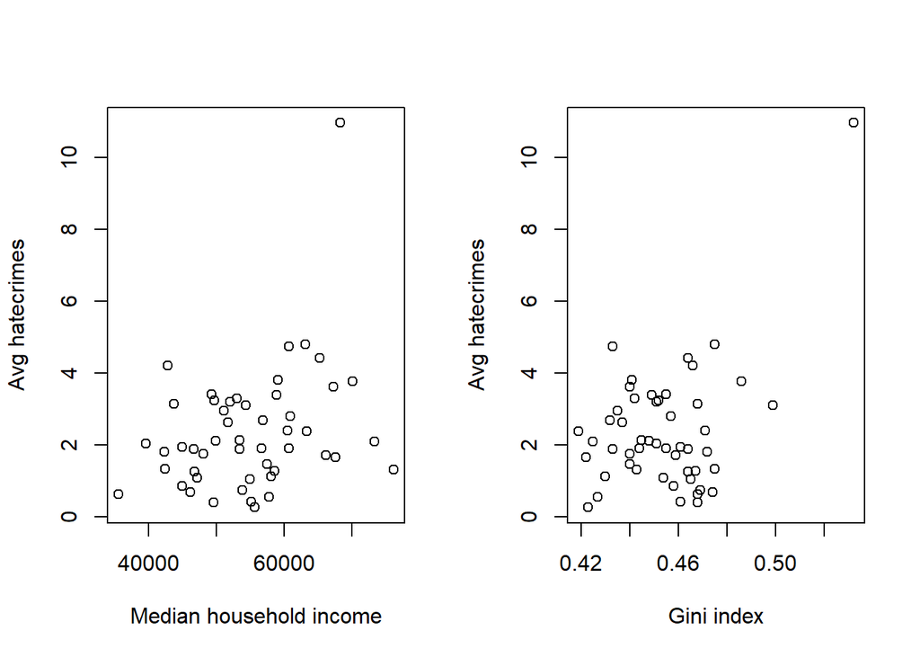

```r
par(mfrow=c(1,2))
plot(inequality$median_household_income, inequality$avg_hatecrimes_per_100k_fbi, xlab='Median household income',ylab='Avg hatecrimes')
plot(inequality$gini_index, inequality$avg_hatecrimes_per_100k_fbi,xlab='Gini index',ylab='Avg hatecrimes')
```

```r
cor(inequality[,c(2,8,12)], use="complete.obs") #calculate correlations where we use only rows that have all values (no NAs). We are only focusing on columns: 2,8 and 12. inequality is a data frame with (n rows, m columns), so we can access only first row by calling inequality[1,], or just first column by inequality[,1], first row and first column would be inequality[1,1]. When using inequality[,c(2,8,12)] am asking for all rows but only second, eight and twelfth column.
```

```
##                             median_household_income gini_index
## median_household_income                   1.0000000 -0.1497444
## gini_index                               -0.1497444  1.0000000
## avg_hatecrimes_per_100k_fbi               0.3182464  0.4212719
##                             avg_hatecrimes_per_100k_fbi
## median_household_income                       0.3182464
## gini_index                                    0.4212719
## avg_hatecrimes_per_100k_fbi                   1.0000000
```

Stepwise approach in building linear model

```r
mod1<-lm(avg_hatecrimes_per_100k_fbi~median_household_income, data=inequality) #modelling avg hatecrimes as a function of median_household_income
summary(mod1)
```

```
##
## Call:
## lm(formula = avg_hatecrimes_per_100k_fbi ~ median_household_income,
##     data = inequality)
##
## Residuals:
##     Min      1Q  Median      3Q     Max
## -2.3300 -1.1183 -0.1656  0.7827  7.7762
##
## Coefficients:
##                           Estimate Std. Error t value Pr(>|t|)
## (Intercept)             -9.564e-01  1.448e+00  -0.661   0.5121
## median_household_income  6.054e-05  2.603e-05   2.326   0.0243 *
## ---
## Signif. codes:  0 '***' 0.001 '**' 0.01 '*' 0.05 '.' 0.1 ' ' 1
##
## Residual standard error: 1.642 on 48 degrees of freedom
##   (1 observation deleted due to missingness)
## Multiple R-squared:  0.1013, Adjusted R-squared:  0.08256
## F-statistic: 5.409 on 1 and 48 DF,  p-value: 0.0243
```

Adding a new predictor and comparing it with the previous model.

```r
mod2<-lm(avg_hatecrimes_per_100k_fbi~median_household_income+gini_index, data=inequality)
anova(mod2) #anova type comparison of the model that allows us to see whether newly added predictor explained additional variation in the outcome. We can see changes in the Sum Sq for residuals and for the main effects
```

```
## Analysis of Variance Table
##
## Response: avg_hatecrimes_per_100k_fbi
##                         Df Sum Sq Mean Sq F value    Pr(>F)
## median_household_income  1 14.584  14.584  7.0649 0.0107093 *
## gini_index               1 32.389  32.389 15.6906 0.0002517 ***
## Residuals               47 97.020   2.064
## ---
## Signif. codes:  0 '***' 0.001 '**' 0.01 '*' 0.05 '.' 0.1 ' ' 1
```

We can also test whether there is need to adjust influence of median household income across the values of gini index - interaction between our predictors

```r
mod3<-lm(avg_hatecrimes_per_100k_fbi~median_household_income*gini_index, data=inequality)
anova(mod1,mod2, mod3) # comparison between three models
```

```
## Analysis of Variance Table
##
## Model 1: avg_hatecrimes_per_100k_fbi ~ median_household_income
## Model 2: avg_hatecrimes_per_100k_fbi ~ median_household_income + gini_index
## Model 3: avg_hatecrimes_per_100k_fbi ~ median_household_income * gini_index
##   Res.Df    RSS Df Sum of Sq      F    Pr(>F)
## 1     48 129.41
## 2     47  97.02  1    32.389 19.742 5.539e-05 ***
## 3     46  75.47  1    21.550 13.135 0.0007218 ***
## ---
## Signif. codes:  0 '***' 0.001 '**' 0.01 '*' 0.05 '.' 0.1 ' ' 1
```

Summary of the model:

```r
summary(mod3)
```

```
##
## Call:
## lm(formula = avg_hatecrimes_per_100k_fbi ~ median_household_income *
##     gini_index, data = inequality)
##
## Residuals:
##      Min       1Q   Median       3Q      Max
## -2.16383 -0.96279 -0.01053  0.88008  2.75763
##
## Coefficients:
##                                      Estimate Std. Error t value Pr(>|t|)
## (Intercept)                         9.056e+01  3.070e+01   2.950 0.004986 **
## median_household_income            -1.724e-03  4.965e-04  -3.472 0.001136 **
## gini_index                         -2.001e+02  6.666e+01  -3.002 0.004330 **
## median_household_income:gini_index  3.907e-03  1.078e-03   3.624 0.000722 ***
## ---
## Signif. codes:  0 '***' 0.001 '**' 0.01 '*' 0.05 '.' 0.1 ' ' 1
##
## Residual standard error: 1.281 on 46 degrees of freedom
##   (1 observation deleted due to missingness)
## Multiple R-squared:  0.4759, Adjusted R-squared:  0.4417
## F-statistic: 13.92 on 3 and 46 DF,  p-value: 1.367e-06
```

We can visualise the interactions using **interactions** package.

```r
require(interactions)
```

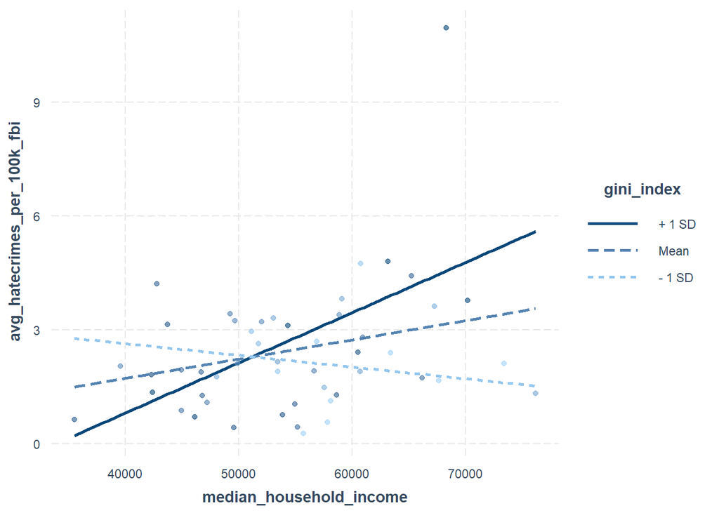

```r
interact_plot(mod3, pred=median_household_income, modx=gini_index, plot.points = T)
```

## Model diagnostics

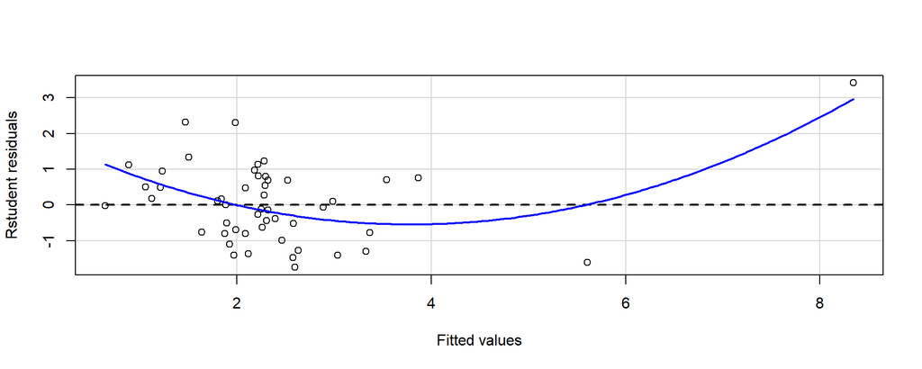

```r
car:: residualPlot(mod3, type='rstudent') # we can call car package without loading it into R environment by calling car::
```

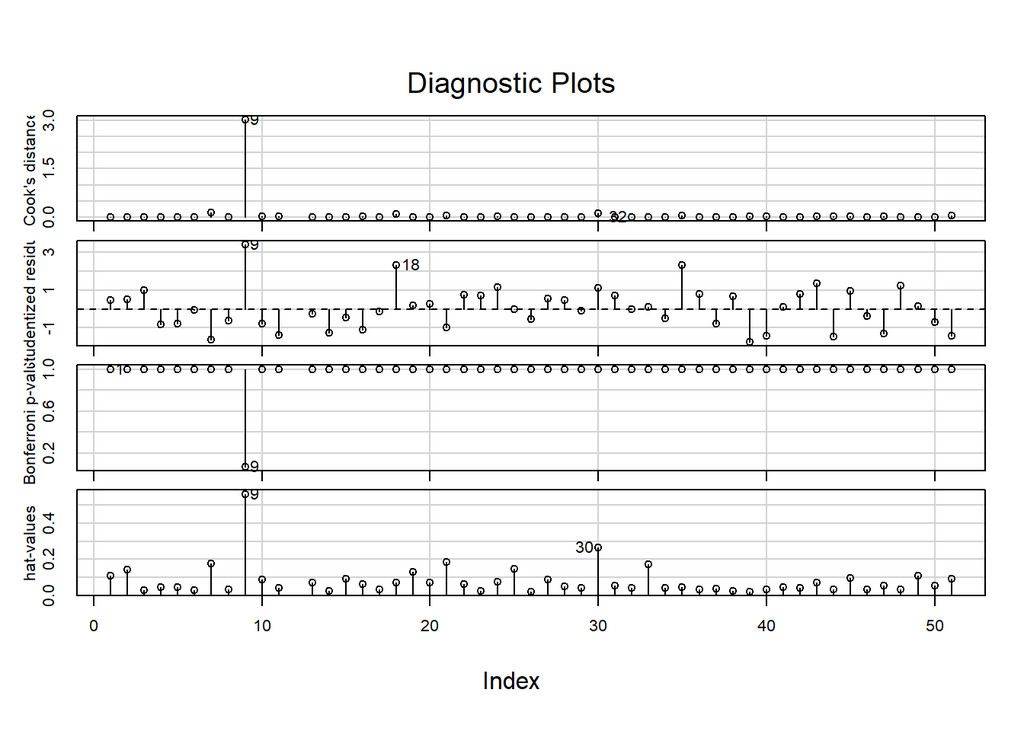

```r
car:: influenceIndexPlot(mod3) #influence of individual observation on our model
```

Finally, we can subset our model and exclude data point that might skew our results

```r
mod3.cor<-lm(avg_hatecrimes_per_100k_fbi~median_household_income*gini_index, data=inequality, subset=-9) #We subset our data to exclude row 9
summary(mod3.cor)
```

```
##
## Call:
## lm(formula = avg_hatecrimes_per_100k_fbi ~ median_household_income *
##     gini_index, data = inequality, subset = -9)
##
## Residuals:
##      Min       1Q   Median       3Q      Max
## -1.90964 -0.94966 -0.08526  0.73470  2.55257
##
## Coefficients:
##                                      Estimate Std. Error t value Pr(>|t|)
## (Intercept)                         4.429e+01  3.080e+01   1.438    0.157
## median_household_income            -7.992e-04  5.228e-04  -1.529    0.133
## gini_index                         -9.668e+01  6.725e+01  -1.438    0.157
## median_household_income:gini_index  1.837e-03  1.145e-03   1.604    0.116
##
## Residual standard error: 1.154 on 45 degrees of freedom
##   (1 observation deleted due to missingness)
## Multiple R-squared:  0.1285, Adjusted R-squared:  0.07041
## F-statistic: 2.212 on 3 and 45 DF,  p-value: 0.09974
```